# Assocation of Modifiable PRS with AD

Shea Andrews

2020-09-24

# Objective

We evaluated the association of 22 PRS for potentially modifiable risk factors with AD in ADGC.

| code | trait | abb |
| --- | --- | --- |
| Liu2019drnkwk23andMe | Alcohol Consumption | Alcohol Consumption |
| Liu2019smkint23andMe | Smoking Initiation | Smoking |
| Liu2019smkcpd23andMe | Cigarettes per Day | Cigarettes per Day |
| SanchezRoige2019auditt23andMe | AUDIT | AUDIT |
| Niarchou2020meat | Meat diet | Meat diet |
| Niarchou2020fish | Fish and Plant diet | Fish & Plant diet |
| Wells2019hdiff | Hearing Difficulties | Hearing Difficulties |
| Xue2018diab | Type 2 Diabetes | Diabetes |
| Yengo2018bmi | BMI | BMI |
| Willer2013tc | Total Cholesterol | Total Cholesterol |
| Willer2013ldl | Low-density lipoproteins | LDL-cholesterol |
| Willer2013hdl | High-density lipoproteins | HDL-cholesterol |
| Willer2013tg | Triglycerides | Triglycerides |
| Evangelou2018dbp | Diastolic Blood Pressure | DBP |
| Evangelou2018sbp | Systolic Blood Pressure | SBP |
| Evangelou2018pp | Pulse Pressure | PP |
| Howard2019dep23andMe | Depressive Symptoms | Depression |
| Jansen2018insomnia23andMe | Insomnia Symptoms | Insomnia |
| Dashti2019slepdur | Sleep Duration | Sleep |
| Day2018sociso | Social Isolation | Social Isolation |
| Lee2018education23andMe | Educational Attainment | Education |
| Huang2017aaos | AAOS | AAOS |
| Deming2017ab42 | AB42 | AB42 |
| Hilbar2017hipv | Hippocampal Volume | Hippocampal Volume |
| Hilbar2015hipv | Hippocampal Volume | Hippocampal Volume |
| Lambert2013load | LOAD | LOAD |
| Kunkle2019load | LOAD | LOAD |
| Beecham2014braak4 | Neurofibrillary Tangles | Neurofibrillary Tangles |
| Beecham2014npany | Neuritic Plaques | Neuritic Plaques |
| Deming2017ptau | Ptau181 | Ptau181 |
| Deming2017tau | Tau | Tau |
| Beecham2014vbiany | Vascular Brain Injury | Vascular Brain Injury |
| Klimentidis2018mvpa | Moderate-to-vigorous PA | Moderate-to-vigorous PA |

# Methods

The software package PRSice-2 was used to construct polygenic risk scores for each of the exposures of interest in ADGC. PRSice generates PRS as the sum of all alleles associated with the exposure of interest exceeding a given P-value threshold (Pt), weighted by their effect size estimated in an independent GWAS on the trait. SNPs were clumped to obtain variants in linkage equilibrium with an r2 > 0.001 within a 10MB window and PRS were constructed across a range of Pt (Pt = 5e-8, 1e-6, 1e-5, 1e-4, 1e-3, 0.01, 0.05, 0.1, 0.2, 0.3, 0.4, and 0.5). The optimal P-value threshold was determined according to the results of a linear regression (PRSice uses linear regression with binary traits to avoid issues of perfect separation during permutation) testing the association of the trait PRS and the AD outcome, adjusted for age, sex, APOE 4 dose, and 10 principal components; the PRS Pt with the smallest P-value of association is selected for association analysis. To guard against overfitting, 1000 permutations were conducted to obtain an empirical P-value for each PRS-AD association. PRS were standardized to have a mean of 0 and SD of 1. After obtaining the optimal Pt the association between each exposure PRS and AD was evaluated using logistic regression adjusting for age, sex, APOE 4 dose, and 10 principal components. The Benjamini & Hochberg false discovery rate was used to account for the multiple testing across the 22 different exposures.

# Results

## GWS

Assoction of GWS PRS with AD

| trait | n SNP | b (se) | OR (95% CI) | p.value | fdr |
| --- | --- | --- | --- | --- | --- |
| Educational Attainment | 424 | -0.066 (0.014) | 0.94 [0.91, 0.96] | 3.8e-06 | 8.4e-05 |
| Diastolic Blood Pressure | 381 | -0.03 (0.014) | 0.97 [0.94, 1] | 0.032 | 0.354 |
| AUDIT | 10 | 0.028 (0.014) | 1.03 [1, 1.06] | 0.05 | 0.363 |
| Cigarettes per Day | 39 | -0.024 (0.014) | 0.98 [0.95, 1] | 0.091 | 0.391 |
| Systolic Blood Pressure | 392 | -0.023 (0.014) | 0.98 [0.95, 1] | 0.098 | 0.391 |
| Low-density lipoproteins | 70 | -0.022 (0.014) | 0.98 [0.95, 1.01] | 0.117 | 0.391 |
| Pulse Pressure | 332 | -0.022 (0.014) | 0.98 [0.95, 1.01] | 0.124 | 0.391 |
| Total Cholesterol | 80 | -0.018 (0.014) | 0.98 [0.96, 1.01] | 0.201 | 0.552 |
| Meat diet | 20 | -0.015 (0.014) | 0.98 [0.96, 1.01] | 0.283 | 0.68 |
| Social Isolation | 13 | -0.014 (0.014) | 0.99 [0.96, 1.01] | 0.309 | 0.68 |
| Depressive Symptoms | 77 | -0.013 (0.014) | 0.99 [0.96, 1.01] | 0.357 | 0.68 |
| BMI | 449 | -0.013 (0.014) | 0.99 [0.96, 1.02] | 0.371 | 0.68 |
| Smoking Initiation | 307 | -0.011 (0.014) | 0.99 [0.96, 1.02] | 0.436 | 0.71 |
| Fish and Plant diet | 41 | 0.009 (0.014) | 1.01 [0.98, 1.04] | 0.504 | 0.71 |
| Hearing Difficulties | 35 | -0.009 (0.014) | 0.99 [0.96, 1.02] | 0.504 | 0.71 |
| Insomnia Symptoms | 139 | 0.009 (0.014) | 1.01 [0.98, 1.04] | 0.536 | 0.71 |
| Alcohol Consumption | 71 | 0.009 (0.014) | 1.01 [0.98, 1.04] | 0.548 | 0.71 |
| Triglycerides | 52 | -0.007 (0.014) | 0.99 [0.97, 1.02] | 0.644 | 0.787 |
| Sleep Duration | 58 | 0.004 (0.014) | 1 [0.98, 1.03] | 0.761 | 0.842 |
| Type 2 Diabetes | 111 | -0.004 (0.014) | 1 [0.97, 1.02] | 0.783 | 0.842 |
| Moderate-to-vigorous PA | 18 | 0.004 (0.014) | 1 [0.98, 1.03] | 0.804 | 0.842 |
| High-density lipoproteins | 84 | -0.002 (0.014) | 1 [0.97, 1.03] | 0.899 | 0.899 |

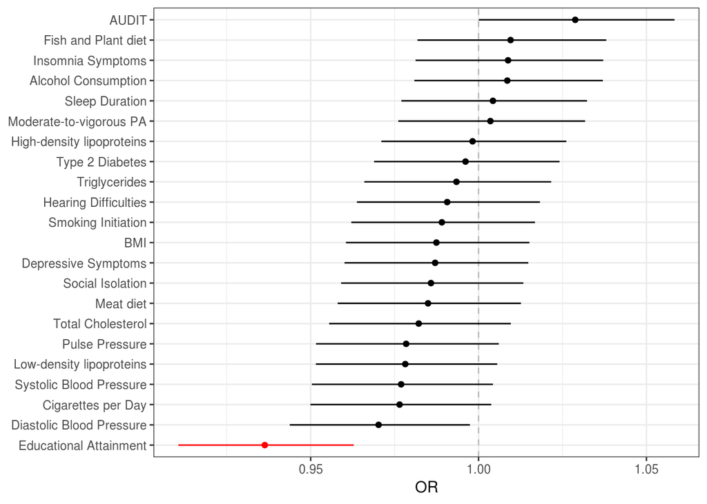

## Best Pt

Assoction of best PRS threshold with AD

| trait | n SNP | b (se) | OR (95% CI) | p.value | fdr |
| --- | --- | --- | --- | --- | --- |
| Educational Attainment | 797 | -0.07 (0.014) | 0.93 [0.91, 0.96] | 8.0e-07 | 1.8e-05 |
| Moderate-to-vigorous PA | 234 | 0.039 (0.014) | 1.04 [1.01, 1.07] | 0.005 | 0.044 |
| Diastolic Blood Pressure | 863 | -0.039 (0.014) | 0.96 [0.94, 0.99] | 0.006 | 0.044 |
| Total Cholesterol | 1341 | 0.029 (0.014) | 1.03 [1, 1.06] | 0.042 | 0.175 |
| Social Isolation | 858 | 0.028 (0.014) | 1.03 [1, 1.06] | 0.047 | 0.175 |
| AUDIT | 10 | 0.028 (0.014) | 1.03 [1, 1.06] | 0.05 | 0.175 |
| Meat diet | 47 | -0.027 (0.014) | 0.97 [0.95, 1] | 0.056 | 0.175 |
| Systolic Blood Pressure | 475 | -0.025 (0.014) | 0.98 [0.95, 1] | 0.081 | 0.2 |
| Hearing Difficulties | 61 | -0.024 (0.014) | 0.98 [0.95, 1] | 0.083 | 0.2 |
| Cigarettes per Day | 39 | -0.024 (0.014) | 0.98 [0.95, 1] | 0.091 | 0.2 |
| Low-density lipoproteins | 70 | -0.022 (0.014) | 0.98 [0.95, 1.01] | 0.117 | 0.228 |
| Pulse Pressure | 332 | -0.022 (0.014) | 0.98 [0.95, 1.01] | 0.124 | 0.228 |
| Alcohol Consumption | 123 | 0.018 (0.014) | 1.02 [0.99, 1.05] | 0.2 | 0.338 |
| Smoking Initiation | 419 | -0.014 (0.014) | 0.99 [0.96, 1.01] | 0.324 | 0.453 |
| Triglycerides | 1531 | -0.014 (0.014) | 0.99 [0.96, 1.01] | 0.327 | 0.453 |
| High-density lipoproteins | 1397 | 0.013 (0.014) | 1.01 [0.99, 1.04] | 0.347 | 0.453 |
| Depressive Symptoms | 77 | -0.013 (0.014) | 0.99 [0.96, 1.01] | 0.357 | 0.453 |
| BMI | 449 | -0.013 (0.014) | 0.99 [0.96, 1.02] | 0.371 | 0.453 |
| Fish and Plant diet | 81 | -0.012 (0.014) | 0.99 [0.96, 1.02] | 0.402 | 0.465 |
| Insomnia Symptoms | 515 | -0.009 (0.014) | 0.99 [0.96, 1.02] | 0.528 | 0.555 |
| Sleep Duration | 593 | 0.009 (0.014) | 1.01 [0.98, 1.04] | 0.53 | 0.555 |
| Type 2 Diabetes | 346 | 0.008 (0.014) | 1.01 [0.98, 1.04] | 0.577 | 0.577 |

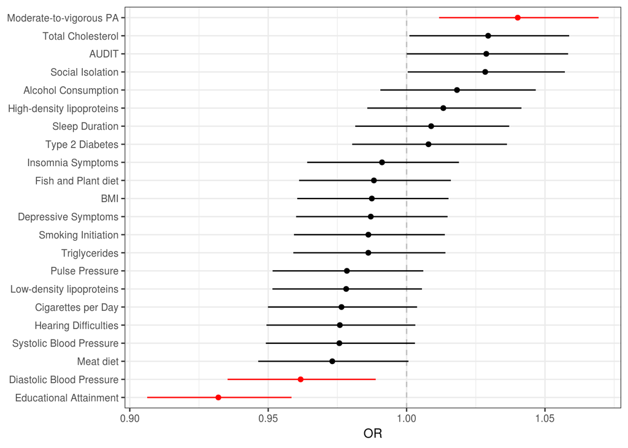

## PRS-PCA

Assoction of best PRS threshold with AD

| trait | n SNP | b (se) | OR (95% CI) | p.value | fdr |
| --- | --- | --- | --- | --- | --- |
| Educational Attainment | 797 | -0.07 (0.014) | 0.93 [0.91, 0.96] | 8.9e-07 | 2.0e-05 |
| Diastolic Blood Pressure | 863 | -0.038 (0.014) | 0.96 [0.94, 0.99] | 0.007 | 0.076 |
| Meat diet | 47 | -0.026 (0.014) | 0.97 [0.95, 1] | 0.063 | 0.459 |
| Social Isolation | 858 | 0.022 (0.014) | 1.02 [0.99, 1.05] | 0.115 | 0.635 |
| Systolic Blood Pressure | 475 | -0.019 (0.014) | 0.98 [0.95, 1.01] | 0.184 | 0.81 |
| Moderate-to-vigorous PA | 234 | 0.017 (0.014) | 1.02 [0.99, 1.05] | 0.233 | 0.825 |
| Cigarettes per Day | 39 | -0.014 (0.014) | 0.99 [0.96, 1.01] | 0.31 | 0.825 |
| Total Cholesterol | 1341 | 0.014 (0.014) | 1.01 [0.99, 1.04] | 0.336 | 0.825 |
| Hearing Difficulties | 61 | -0.013 (0.014) | 0.99 [0.96, 1.01] | 0.351 | 0.825 |
| AUDIT | 10 | -0.012 (0.014) | 0.99 [0.96, 1.02] | 0.393 | 0.825 |
| Pulse Pressure | 332 | -0.012 (0.014) | 0.99 [0.96, 1.02] | 0.419 | 0.825 |
| Alcohol Consumption | 123 | 0.011 (0.014) | 1.01 [0.98, 1.04] | 0.45 | 0.825 |
| Smoking Initiation | 419 | -0.009 (0.014) | 0.99 [0.96, 1.02] | 0.516 | 0.872 |
| BMI | 449 | -0.008 (0.014) | 0.99 [0.97, 1.02] | 0.573 | 0.901 |
| Triglycerides | 1531 | -0.006 (0.014) | 0.99 [0.97, 1.02] | 0.652 | 0.956 |
| High-density lipoproteins | 1397 | 0.005 (0.014) | 1 [0.98, 1.03] | 0.728 | 0.961 |
| Depressive Symptoms | 77 | -0.005 (0.014) | 1 [0.97, 1.02] | 0.743 | 0.961 |
| Type 2 Diabetes | 346 | 0.004 (0.014) | 1 [0.98, 1.03] | 0.807 | 0.968 |
| Sleep Duration | 593 | 0.002 (0.014) | 1 [0.97, 1.03] | 0.871 | 0.968 |
| Insomnia Symptoms | 515 | -0.001 (0.014) | 1 [0.97, 1.03] | 0.939 | 0.968 |
| Low-density lipoproteins | 70 | -0.001 (0.014) | 1 [0.97, 1.03] | 0.965 | 0.968 |
| Fish and Plant diet | 81 | 0.001 (0.014) | 1 [0.97, 1.03] | 0.968 | 0.968 |

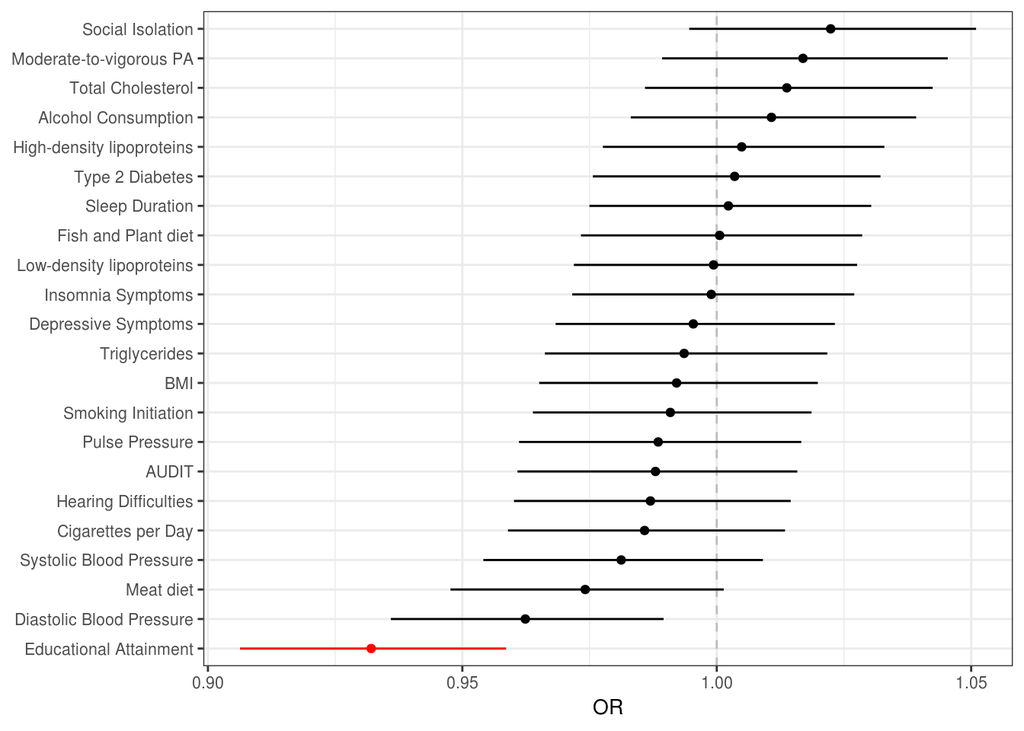

## GWS vs Best vs PCA

Comparison of GWS and Best pt Results

| trait | GWS n SNP | GWS b (se) | GWS p | GWS fdr | GWS OR (95% CI) | Best Pt pt_best | Best Pt Num_SNP_best | Best Pt b_se_best | Best Pt p.value_best | Best Pt fdr_best | Best Pt out_best | PRS-PCA b_se_PCA | PRS-PCA p.value_PCA | PRS-PCA fdr_PCA | PRS-PCA out_PCA |
| --- | --- | --- | --- | --- | --- | --- | --- | --- | --- | --- | --- | --- | --- | --- | --- |
| Educational Attainment | 424 | -0.066 (0.014) | 3.8e-06 | 8.4e-05 | 0.94 [0.91, 0.96] | 1e-04 | 797 | -0.07 (0.014) | 8.0e-07 | 1.8e-05 | 0.93 [0.91, 0.96] | -0.07 (0.014) | 8.9e-07 | 2.0e-05 | 0.93 [0.91, 0.96] |
| Diastolic Blood Pressure | 381 | -0.03 (0.014) | 0.032 | 0.354 | 0.97 [0.94, 1] | 0.001 | 863 | -0.039 (0.014) | 0.006 | 0.044 | 0.96 [0.94, 0.99] | -0.038 (0.014) | 0.007 | 0.076 | 0.96 [0.94, 0.99] |
| AUDIT | 10 | 0.028 (0.014) | 0.05 | 0.363 | 1.03 [1, 1.06] | 5e-08 | 10 | 0.028 (0.014) | 0.05 | 0.175 | 1.03 [1, 1.06] | -0.012 (0.014) | 0.393 | 0.825 | 0.99 [0.96, 1.02] |
| Cigarettes per Day | 39 | -0.024 (0.014) | 0.091 | 0.391 | 0.98 [0.95, 1] | 5e-08 | 39 | -0.024 (0.014) | 0.091 | 0.2 | 0.98 [0.95, 1] | -0.014 (0.014) | 0.31 | 0.825 | 0.99 [0.96, 1.01] |
| Systolic Blood Pressure | 392 | -0.023 (0.014) | 0.098 | 0.391 | 0.98 [0.95, 1] | 1e-06 | 475 | -0.025 (0.014) | 0.081 | 0.2 | 0.98 [0.95, 1] | -0.019 (0.014) | 0.184 | 0.81 | 0.98 [0.95, 1.01] |
| Low-density lipoproteins | 70 | -0.022 (0.014) | 0.117 | 0.391 | 0.98 [0.95, 1.01] | 5e-08 | 70 | -0.022 (0.014) | 0.117 | 0.228 | 0.98 [0.95, 1.01] | -0.001 (0.014) | 0.965 | 0.968 | 1 [0.97, 1.03] |
| Pulse Pressure | 332 | -0.022 (0.014) | 0.124 | 0.391 | 0.98 [0.95, 1.01] | 5e-08 | 332 | -0.022 (0.014) | 0.124 | 0.228 | 0.98 [0.95, 1.01] | -0.012 (0.014) | 0.419 | 0.825 | 0.99 [0.96, 1.02] |
| Total Cholesterol | 80 | -0.018 (0.014) | 0.201 | 0.552 | 0.98 [0.96, 1.01] | 0.3 | 1341 | 0.029 (0.014) | 0.042 | 0.175 | 1.03 [1, 1.06] | 0.014 (0.014) | 0.336 | 0.825 | 1.01 [0.99, 1.04] |
| Meat diet | 20 | -0.015 (0.014) | 0.283 | 0.68 | 0.98 [0.96, 1.01] | 1e-06 | 47 | -0.027 (0.014) | 0.056 | 0.175 | 0.97 [0.95, 1] | -0.026 (0.014) | 0.063 | 0.459 | 0.97 [0.95, 1] |
| Social Isolation | 13 | -0.014 (0.014) | 0.309 | 0.68 | 0.99 [0.96, 1.01] | 0.01 | 858 | 0.028 (0.014) | 0.047 | 0.175 | 1.03 [1, 1.06] | 0.022 (0.014) | 0.115 | 0.635 | 1.02 [0.99, 1.05] |
| Depressive Symptoms | 77 | -0.013 (0.014) | 0.357 | 0.68 | 0.99 [0.96, 1.01] | 5e-08 | 77 | -0.013 (0.014) | 0.357 | 0.453 | 0.99 [0.96, 1.01] | -0.005 (0.014) | 0.743 | 0.961 | 1 [0.97, 1.02] |
| BMI | 449 | -0.013 (0.014) | 0.371 | 0.68 | 0.99 [0.96, 1.02] | 5e-08 | 449 | -0.013 (0.014) | 0.371 | 0.453 | 0.99 [0.96, 1.02] | -0.008 (0.014) | 0.573 | 0.901 | 0.99 [0.97, 1.02] |
| Smoking Initiation | 307 | -0.011 (0.014) | 0.436 | 0.71 | 0.99 [0.96, 1.02] | 1e-06 | 419 | -0.014 (0.014) | 0.324 | 0.453 | 0.99 [0.96, 1.01] | -0.009 (0.014) | 0.516 | 0.872 | 0.99 [0.96, 1.02] |
| Fish and Plant diet | 41 | 0.009 (0.014) | 0.504 | 0.71 | 1.01 [0.98, 1.04] | 1e-06 | 81 | -0.012 (0.014) | 0.402 | 0.465 | 0.99 [0.96, 1.02] | 0.001 (0.014) | 0.968 | 0.968 | 1 [0.97, 1.03] |
| Hearing Difficulties | 35 | -0.009 (0.014) | 0.504 | 0.71 | 0.99 [0.96, 1.02] | 1e-06 | 61 | -0.024 (0.014) | 0.083 | 0.2 | 0.98 [0.95, 1] | -0.013 (0.014) | 0.351 | 0.825 | 0.99 [0.96, 1.01] |
| Insomnia Symptoms | 139 | 0.009 (0.014) | 0.536 | 0.71 | 1.01 [0.98, 1.04] | 1e-04 | 515 | -0.009 (0.014) | 0.528 | 0.555 | 0.99 [0.96, 1.02] | -0.001 (0.014) | 0.939 | 0.968 | 1 [0.97, 1.03] |
| Alcohol Consumption | 71 | 0.009 (0.014) | 0.548 | 0.71 | 1.01 [0.98, 1.04] | 1e-06 | 123 | 0.018 (0.014) | 0.2 | 0.338 | 1.02 [0.99, 1.05] | 0.011 (0.014) | 0.45 | 0.825 | 1.01 [0.98, 1.04] |
| Triglycerides | 52 | -0.007 (0.014) | 0.644 | 0.787 | 0.99 [0.97, 1.02] | 1 | 1531 | -0.014 (0.014) | 0.327 | 0.453 | 0.99 [0.96, 1.01] | -0.006 (0.014) | 0.652 | 0.956 | 0.99 [0.97, 1.02] |
| Sleep Duration | 58 | 0.004 (0.014) | 0.761 | 0.842 | 1 [0.98, 1.03] | 0.001 | 593 | 0.009 (0.014) | 0.53 | 0.555 | 1.01 [0.98, 1.04] | 0.002 (0.014) | 0.871 | 0.968 | 1 [0.97, 1.03] |
| Type 2 Diabetes | 111 | -0.004 (0.014) | 0.783 | 0.842 | 1 [0.97, 1.02] | 1e-04 | 346 | 0.008 (0.014) | 0.577 | 0.577 | 1.01 [0.98, 1.04] | 0.004 (0.014) | 0.807 | 0.968 | 1 [0.98, 1.03] |
| Moderate-to-vigorous PA | 18 | 0.004 (0.014) | 0.804 | 0.842 | 1 [0.98, 1.03] | 1e-04 | 234 | 0.039 (0.014) | 0.005 | 0.044 | 1.04 [1.01, 1.07] | 0.017 (0.014) | 0.233 | 0.825 | 1.02 [0.99, 1.05] |
| High-density lipoproteins | 84 | -0.002 (0.014) | 0.899 | 0.899 | 1 [0.97, 1.03] | 0.4 | 1397 | 0.013 (0.014) | 0.347 | 0.453 | 1.01 [0.99, 1.04] | 0.005 (0.014) | 0.728 | 0.961 | 1 [0.98, 1.03] |

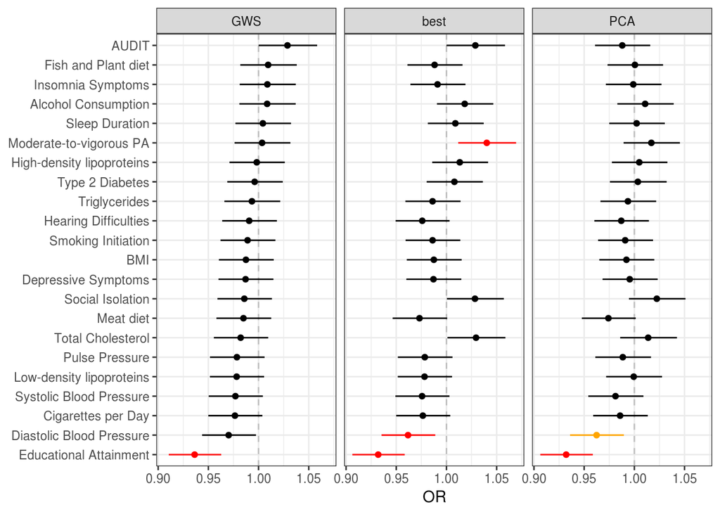